# Project: Wrangling and Analyze Data

## Data Gathering

In the cell below, gather **all** three pieces of data for this project and load them in the notebook. **Note:** the methods required to gather each data are different.

1. Directly download the WeRateDogs Twitter archive data (twitter_archive_enhanced.csv)

```python
import pandas as pd
```

```python
twitter_archive_df = pd.read_csv("twitter-archive-enhanced.csv")
twitter_archive_df.head()
```

|  | tweet_id | in_reply_to_status_id | in_reply_to_user_id | timestamp | source | text | retweeted_status_id | retweeted_status_user_id | retweeted_status_timestamp | expanded_urls | rating_numerator | rating_denominator | name | doggo | floofer | pupper | puppo |
| --- | --- | --- | --- | --- | --- | --- | --- | --- | --- | --- | --- | --- | --- | --- | --- | --- | --- |
| 0 | 892420643555336193 | NaN | NaN | 2017-08-01 16:23:56 +0000 | <a href="http://twitter.com/download/iphone" r... | This is Phineas. He's a mystical boy. Only eve... | NaN | NaN | NaN | https://twitter.com/dog_rates/status/892420643... | 13 | 10 | Phineas | None | None | None | None |
| 1 | 892177421306343426 | NaN | NaN | 2017-08-01 00:17:27 +0000 | <a href="http://twitter.com/download/iphone" r... | This is Tilly. She's just checking pup on you.... | NaN | NaN | NaN | https://twitter.com/dog_rates/status/892177421... | 13 | 10 | Tilly | None | None | None | None |
| 2 | 891815181378084864 | NaN | NaN | 2017-07-31 00:18:03 +0000 | <a href="http://twitter.com/download/iphone" r... | This is Archie. He is a rare Norwegian Pouncin... | NaN | NaN | NaN | https://twitter.com/dog_rates/status/891815181... | 12 | 10 | Archie | None | None | None | None |
| 3 | 891689557279858688 | NaN | NaN | 2017-07-30 15:58:51 +0000 | <a href="http://twitter.com/download/iphone" r... | This is Darla. She commenced a snooze mid meal... | NaN | NaN | NaN | https://twitter.com/dog_rates/status/891689557... | 13 | 10 | Darla | None | None | None | None |
| 4 | 891327558926688256 | NaN | NaN | 2017-07-29 16:00:24 +0000 | <a href="http://twitter.com/download/iphone" r... | This is Franklin. He would like you to stop ca... | NaN | NaN | NaN | https://twitter.com/dog_rates/status/891327558... | 12 | 10 | Franklin | None | None | None | None |

1. Use the Requests library to download the tweet image prediction (image_predictions.tsv)

```python
import requests

url="https://d17h27t6h515a5.cloudfront.net/topher/2017/August/599fd2ad_image-predictions/image-predictions.tsv"
response = requests.get(url)
with open('image_predictions.tsv', 'wb') as file:
    file.write(response.content)
```

```python
image_predictions_df = pd.read_csv('image_predictions.tsv', sep='\t')
image_predictions_df.head()
```

|  | tweet_id | jpg_url | img_num | p1 | p1_conf | p1_dog | p2 | p2_conf | p2_dog | p3 | p3_conf | p3_dog |
| --- | --- | --- | --- | --- | --- | --- | --- | --- | --- | --- | --- | --- |
| 0 | 666020888022790149 | https://pbs.twimg.com/media/CT4udn0WwAA0aMy.jpg | 1 | Welsh_springer_spaniel | 0.465074 | True | collie | 0.156665 | True | Shetland_sheepdog | 0.061428 | True |
| 1 | 666029285002620928 | https://pbs.twimg.com/media/CT42GRgUYAA5iDo.jpg | 1 | redbone | 0.506826 | True | miniature_pinscher | 0.074192 | True | Rhodesian_ridgeback | 0.072010 | True |
| 2 | 666033412701032449 | https://pbs.twimg.com/media/CT4521TWwAEvMyu.jpg | 1 | German_shepherd | 0.596461 | True | malinois | 0.138584 | True | bloodhound | 0.116197 | True |
| 3 | 666044226329800704 | https://pbs.twimg.com/media/CT5Dr8HUEAA-lEu.jpg | 1 | Rhodesian_ridgeback | 0.408143 | True | redbone | 0.360687 | True | miniature_pinscher | 0.222752 | True |
| 4 | 666049248165822465 | https://pbs.twimg.com/media/CT5IQmsXIAAKY4A.jpg | 1 | miniature_pinscher | 0.560311 | True | Rottweiler | 0.243682 | True | Doberman | 0.154629 | True |

```python
image_predictions_df.to_csv("image_predictions.csv")
```

1. Use the Tweepy library to query additional data via the Twitter API (tweet_json.txt)

```python
# import tweepy
# from tweepy import OAuthHandler
# import json
# from timeit import default_timer as timer
```

Just to save time, I've commented the code below and you can use the saved file "tweet_json.txt"

```python
# consumer_key = ''
# consumer_secret = ''
# access_token = ''
# access_secret = ''

# auth = OAuthHandler(consumer_key, consumer_secret)
# auth.set_access_token(access_token, access_secret)

# api = tweepy.API(auth, wait_on_rate_limit=True)
```

```python
# tweet_ids = df.tweet_id.values
# len(tweet_ids)

# # Query Twitter's API for JSON data for each tweet ID in the Twitter archive
# count = 0
# fails_dict = {}
# start = timer()
# # Save each tweet's returned JSON as a new line in a .txt file
# with open('tweet_json.txt', 'w') as outfile:
#     # This loop will likely take 20-30 minutes to run because of Twitter's rate limit
#     for tweet_id in tweet_ids:
#         count += 1
#         print(str(count) + ": " + str(tweet_id))
#         try:
#             tweet = api.get_status(tweet_id, tweet_mode='extended')
#             print("Success")
#             json.dump(tweet._json, outfile)
#             outfile.write('\n')
#         except tweepy.TweepError as e:
#             print("Fail")
#             fails_dict[tweet_id] = e
#             pass
# end = timer()
# print(end - start)
# print(fails_dict)
```

[output not shown]

[output cut: 4659 more lines]

[output not shown]

```python
twitter_df = pd.read_json("tweet_json.txt", lines=True)
twitter_df.head()
```

|  | contributors | coordinates | created_at | display_text_range | entities | extended_entities | favorite_count | favorited | full_text | geo | ... | quoted_status | quoted_status_id | quoted_status_id_str | quoted_status_permalink | retweet_count | retweeted | retweeted_status | source | truncated | user |
| --- | --- | --- | --- | --- | --- | --- | --- | --- | --- | --- | --- | --- | --- | --- | --- | --- | --- | --- | --- | --- | --- |
| 0 | NaN | NaN | 2017-08-01 16:23:56 | [0, 85] | {'hashtags': [], 'symbols': [], 'user_mentions... | {'media': [{'id': 892420639486877696, 'id_str'... | 32923 | False | This is Phineas. He's a mystical boy. Only eve... | NaN | ... | NaN | NaN | NaN | NaN | 6881 | False | NaN | <a href="http://twitter.com/download/iphone" r... | False | {'id': 4196983835, 'id_str': '4196983835', 'na... |
| 1 | NaN | NaN | 2017-08-01 00:17:27 | [0, 138] | {'hashtags': [], 'symbols': [], 'user_mentions... | {'media': [{'id': 892177413194625024, 'id_str'... | 28457 | False | This is Tilly. She's just checking pup on you.... | NaN | ... | NaN | NaN | NaN | NaN | 5180 | False | NaN | <a href="http://twitter.com/download/iphone" r... | False | {'id': 4196983835, 'id_str': '4196983835', 'na... |
| 2 | NaN | NaN | 2017-07-31 00:18:03 | [0, 121] | {'hashtags': [], 'symbols': [], 'user_mentions... | {'media': [{'id': 891815175371796480, 'id_str'... | 21382 | False | This is Archie. He is a rare Norwegian Pouncin... | NaN | ... | NaN | NaN | NaN | NaN | 3423 | False | NaN | <a href="http://twitter.com/download/iphone" r... | False | {'id': 4196983835, 'id_str': '4196983835', 'na... |
| 3 | NaN | NaN | 2017-07-30 15:58:51 | [0, 79] | {'hashtags': [], 'symbols': [], 'user_mentions... | {'media': [{'id': 891689552724799489, 'id_str'... | 35889 | False | This is Darla. She commenced a snooze mid meal... | NaN | ... | NaN | NaN | NaN | NaN | 7089 | False | NaN | <a href="http://twitter.com/download/iphone" r... | False | {'id': 4196983835, 'id_str': '4196983835', 'na... |
| 4 | NaN | NaN | 2017-07-29 16:00:24 | [0, 138] | {'hashtags': [{'text': 'BarkWeek', 'indices': ... | {'media': [{'id': 891327551943041024, 'id_str'... | 34324 | False | This is Franklin. He would like you to stop ca... | NaN | ... | NaN | NaN | NaN | NaN | 7606 | False | NaN | <a href="http://twitter.com/download/iphone" r... | False | {'id': 4196983835, 'id_str': '4196983835', 'na... |

5 rows × 32 columns

```python
twitter_df.to_csv("additional_twitter_data.csv")
```

## Assessing Data

In this section, detect and document at least **eight (8) quality issues and two (2) tidiness issue**. You must use **both** visual assessment programmatic assessement to assess the data.

**Note:** pay attention to the following key points when you access the data.

- You only want original ratings (no retweets) that have images. Though there are 5000+ tweets in the dataset, not all are dog ratings and some are retweets.
- Assessing and cleaning the entire dataset completely would require a lot of time, and is not necessary to practice and demonstrate your skills in data wrangling. Therefore, the requirements of this project are only to assess and clean at least 8 quality issues and at least 2 tidiness issues in this dataset.
- The fact that the rating numerators are greater than the denominators does not need to be cleaned. This [unique rating system](http://knowyourmeme.com/memes/theyre-good-dogs-brent) is a big part of the popularity of WeRateDogs.
- You do not need to gather the tweets beyond August 1st, 2017. You can, but note that you won't be able to gather the image predictions for these tweets since you don't have access to the algorithm used.

### Quality issues

- twitter_archive : Clean source coulmn to be clearly expressed
- twitter_archive: Timestamp should be datatime
- twitter_archive : Convert tweet_id to string
- twitter_archive : Some dogs have more than one stage
- twitter_archive : Convert dog_stage to category data type
- twitter_archive : Drop unsued columns
- twitter_df : Convert id to string
- twitter_df : Remove unused columns
- image_predictions_df : Convert tweet_id to string

## Cleaning Data

In this section, clean **all** of the issues you documented while assessing.

**Note:** Make a copy of the original data before cleaning. Cleaning includes merging individual pieces of data according to the rules of [tidy data](https://cran.r-project.org/web/packages/tidyr/vignettes/tidy-data.html). The result should be a high-quality and tidy master pandas DataFrame (or DataFrames, if appropriate).

```python
# Make copies of original pieces of data
twitter_archive_df_copy = twitter_archive_df.copy()
image_predictions_df_copy = image_predictions_df.copy()
twitter_df_copy = twitter_df.copy()
```

```python
# I will try to quickly look at the data and check most frequent issues
# like data types, null values
```

```python
twitter_archive_df_copy.info()
```

[output not shown]

```python
# tweet_it, timestamp need to be corrected (str, datetime)
```

```python
twitter_archive_df_copy.head()
```

|  | tweet_id | in_reply_to_status_id | in_reply_to_user_id | timestamp | source | text | retweeted_status_id | retweeted_status_user_id | retweeted_status_timestamp | expanded_urls | rating_numerator | rating_denominator | name | doggo | floofer | pupper | puppo |
| --- | --- | --- | --- | --- | --- | --- | --- | --- | --- | --- | --- | --- | --- | --- | --- | --- | --- |
| 0 | 892420643555336193 | NaN | NaN | 2017-08-01 16:23:56 +0000 | <a href="http://twitter.com/download/iphone" r... | This is Phineas. He's a mystical boy. Only eve... | NaN | NaN | NaN | https://twitter.com/dog_rates/status/892420643... | 13 | 10 | Phineas | None | None | None | None |
| 1 | 892177421306343426 | NaN | NaN | 2017-08-01 00:17:27 +0000 | <a href="http://twitter.com/download/iphone" r... | This is Tilly. She's just checking pup on you.... | NaN | NaN | NaN | https://twitter.com/dog_rates/status/892177421... | 13 | 10 | Tilly | None | None | None | None |
| 2 | 891815181378084864 | NaN | NaN | 2017-07-31 00:18:03 +0000 | <a href="http://twitter.com/download/iphone" r... | This is Archie. He is a rare Norwegian Pouncin... | NaN | NaN | NaN | https://twitter.com/dog_rates/status/891815181... | 12 | 10 | Archie | None | None | None | None |
| 3 | 891689557279858688 | NaN | NaN | 2017-07-30 15:58:51 +0000 | <a href="http://twitter.com/download/iphone" r... | This is Darla. She commenced a snooze mid meal... | NaN | NaN | NaN | https://twitter.com/dog_rates/status/891689557... | 13 | 10 | Darla | None | None | None | None |
| 4 | 891327558926688256 | NaN | NaN | 2017-07-29 16:00:24 +0000 | <a href="http://twitter.com/download/iphone" r... | This is Franklin. He would like you to stop ca... | NaN | NaN | NaN | https://twitter.com/dog_rates/status/891327558... | 12 | 10 | Franklin | None | None | None | None |

```python
image_predictions_df_copy.dtypes
```

```
tweet_id      int64
jpg_url      object
img_num       int64
p1           object
p1_conf     float64
p1_dog         bool
p2           object
p2_conf     float64
p2_dog         bool
p3           object
p3_conf     float64
p3_dog         bool
dtype: object
```

```python
# tweet_id needs to be string
```

```python
twitter_df.info()
```

```
<class 'pandas.core.frame.DataFrame'>
RangeIndex: 2325 entries, 0 to 2324
Data columns (total 32 columns):
contributors                     0 non-null float64
coordinates                      0 non-null float64
created_at                       2325 non-null datetime64[ns]
display_text_range               2325 non-null object
entities                         2325 non-null object
extended_entities                2055 non-null object
favorite_count                   2325 non-null int64
favorited                        2325 non-null bool
full_text                        2325 non-null object
geo                              0 non-null float64
id                               2325 non-null int64
id_str                           2325 non-null int64
in_reply_to_screen_name          77 non-null object
in_reply_to_status_id            77 non-null float64
in_reply_to_status_id_str        77 non-null float64
in_reply_to_user_id              77 non-null float64
in_reply_to_user_id_str          77 non-null float64
is_quote_status                  2325 non-null bool
lang                             2325 non-null object
place                            1 non-null object
possibly_sensitive               2193 non-null float64
possibly_sensitive_appealable    2193 non-null float64
quoted_status                    23 non-null object
quoted_status_id                 26 non-null float64
quoted_status_id_str             26 non-null float64
quoted_status_permalink          26 non-null object
retweet_count                    2325 non-null int64
retweeted                        2325 non-null bool
retweeted_status                 158 non-null object
source                           2325 non-null object
truncated                        2325 non-null bool
user                             2325 non-null object
dtypes: bool(4), datetime64[ns](1), float64(11), int64(4), object(12)
memory usage: 517.8+ KB
```

```python
twitter_archive_df_copy.retweeted_status_user_id.head()
```

```
0   NaN
1   NaN
2   NaN
3   NaN
4   NaN
Name: retweeted_status_user_id, dtype: float64
```

```python
# Some of the tweets are retweeted (retweeted_status_user_id has a value)
# Since we need the original tweets, we need those with NaN retweeted_status_user_id
```

```python
twitter_archive_df_copy = twitter_archive_df_copy[twitter_archive_df_copy["retweeted_status_user_id"].isnull()]
```

```python
twitter_archive_df_copy['retweeted_status_user_id'].value_counts()
```

```
Series([], Name: retweeted_status_user_id, dtype: int64)
```

### Issue #1: Clean source column to be more expressed

#### Define: The source is part of href tags, I want it seperate

#### Code

```python
twitter_archive_df_copy['source'].value_counts()
```

```
<a href="http://twitter.com/download/iphone" rel="nofollow">Twitter for iPhone</a>     2042
<a href="http://vine.co" rel="nofollow">Vine - Make a Scene</a>                          91
<a href="http://twitter.com" rel="nofollow">Twitter Web Client</a>                       31
<a href="https://about.twitter.com/products/tweetdeck" rel="nofollow">TweetDeck</a>      11
Name: source, dtype: int64
```

```python
twitter_archive_df_copy['source'] = twitter_archive_df_copy['source'].str.replace('<a href="http://twitter.com/download/iphone" rel="nofollow">Twitter for iPhone</a>', 'Twitter for iPhone')
twitter_archive_df_copy['source'] = twitter_archive_df_copy['source'].str.replace('<a href="http://vine.co" rel="nofollow">Vine - Make a Scene</a>','Vine - Make a Scene')
twitter_archive_df_copy['source'] = twitter_archive_df_copy['source'].str.replace('<a href="http://twitter.com" rel="nofollow">Twitter Web Client</a>','Twitter Web Client')
twitter_archive_df_copy['source'] = twitter_archive_df_copy['source'].str.replace('<a href="https://about.twitter.com/products/tweetdeck" rel="nofollow">TweetDeck</a>','TweetDeck')
```

#### Test

```python
twitter_archive_df_copy['source'].value_counts()
```

```
Twitter for iPhone     2042
Vine - Make a Scene      91
Twitter Web Client       31
TweetDeck                11
Name: source, dtype: int64
```

### Issue #2: Timestamp should be datatime

#### Define timestampe now is object not datatime

#### Code

```python
twitter_archive_df_copy.dtypes
```

```
tweet_id                        int64
in_reply_to_status_id         float64
in_reply_to_user_id           float64
timestamp                      object
source                         object
text                           object
retweeted_status_id           float64
retweeted_status_user_id      float64
retweeted_status_timestamp     object
expanded_urls                  object
rating_numerator                int64
rating_denominator              int64
name                           object
doggo                          object
floofer                        object
pupper                         object
puppo                          object
dtype: object
```

```python
twitter_archive_df_copy['timestamp'] = pd.to_datetime(twitter_archive_df_copy['timestamp'])
```

#### Test

```python
twitter_archive_df_copy['timestamp'].head()
```

```
0   2017-08-01 16:23:56
1   2017-08-01 00:17:27
2   2017-07-31 00:18:03
3   2017-07-30 15:58:51
4   2017-07-29 16:00:24
Name: timestamp, dtype: datetime64[ns]
```

### Issue #3: Convert tweet_id to string

```python
twitter_archive_df_copy['tweet_id'].dtype
```

```
dtype('int64')
```

```python
twitter_archive_df_copy['tweet_id'] = twitter_archive_df_copy['tweet_id'].astype(str)
```

```python
twitter_archive_df_copy['tweet_id'].dtype
```

```
dtype('O')
```

### Issue #4: Some dogs have more than one stage

```python
twitter_archive_df_copy['stages'] = twitter_archive_df_copy.doggo + twitter_archive_df_copy.floofer + twitter_archive_df_copy.pupper + twitter_archive_df_copy.puppo
twitter_archive_df_copy['stages'].value_counts()
```

```
NoneNoneNoneNone        1831
NoneNonepupperNone       224
doggoNoneNoneNone         75
NoneNoneNonepuppo         24
doggoNonepupperNone       10
NoneflooferNoneNone        9
doggoNoneNonepuppo         1
doggoflooferNoneNone       1
Name: stages, dtype: int64
```

```python
# 3 None + stage = stage
# 2 None = Multiple stages
def check_dog_stage(df):
    if df['stages'].count('None') == 2:
        return 'Multiple'
    else:
        if df['stages'].count('doggo') == 1:
            return 'Doggo'
        elif df['stages'].count('floofer') == 1:
            return 'Floofer'
        elif df['stages'].count('pupper') == 1:
            return 'Pupper'
        elif df['stages'].count('puppo') == 1:
            return 'Puppo'
        else:
            return 'None'
```

```python
twitter_archive_df_copy['dog_stage'] = twitter_archive_df_copy.apply(check_dog_stage, axis=1)
twitter_archive_df_copy['dog_stage'].value_counts()
```

```
None        1831
Pupper       224
Doggo         75
Puppo         24
Multiple      12
Floofer        9
Name: dog_stage, dtype: int64
```

### Issue #5: Convert dog_stage to be category

```python
twitter_archive_df_copy.dog_stage = twitter_archive_df_copy.dog_stage.astype('category')
twitter_archive_df_copy.dog_stage.dtype
```

```
CategoricalDtype(categories=['Doggo', 'Floofer', 'Multiple', 'None', 'Pupper', 'Puppo'], ordered=False)
```

### Issue #6: Drop unused columns

```python
unused_columns = ['in_reply_to_status_id','in_reply_to_user_id','retweeted_status_id','retweeted_status_user_id',
                  'retweeted_status_timestamp', 'expanded_urls','doggo', 'floofer', 'pupper', 'puppo', 'stages']
twitter_archive_df_copy = twitter_archive_df_copy.drop(unused_columns, axis=1)
```

```python
twitter_archive_df_copy.head()
```

|  | tweet_id | timestamp | source | text | rating_numerator | rating_denominator | name | dog_stage |
| --- | --- | --- | --- | --- | --- | --- | --- | --- |
| 0 | 892420643555336193 | 2017-08-01 16:23:56 | Twitter for iPhone | This is Phineas. He's a mystical boy. Only eve... | 13 | 10 | Phineas | None |
| 1 | 892177421306343426 | 2017-08-01 00:17:27 | Twitter for iPhone | This is Tilly. She's just checking pup on you.... | 13 | 10 | Tilly | None |
| 2 | 891815181378084864 | 2017-07-31 00:18:03 | Twitter for iPhone | This is Archie. He is a rare Norwegian Pouncin... | 12 | 10 | Archie | None |
| 3 | 891689557279858688 | 2017-07-30 15:58:51 | Twitter for iPhone | This is Darla. She commenced a snooze mid meal... | 13 | 10 | Darla | None |
| 4 | 891327558926688256 | 2017-07-29 16:00:24 | Twitter for iPhone | This is Franklin. He would like you to stop ca... | 12 | 10 | Franklin | None |

### Issue #7: Twitter_df : convert id to string

```python
twitter_df_copy.id.dtype
```

```
dtype('int64')
```

```python
twitter_df_copy.id = twitter_df_copy.id.astype(str)
```

```python
twitter_df_copy.id.dtype
```

```
dtype('O')
```

### Issue #8: Remove unused columns

```python
columns = ['id','id_str', 'retweet_count', 'favorite_count', 'created_at']
twitter_df_copy = twitter_df_copy[columns]
twitter_df_copy.head()
```

|  | id | id_str | retweet_count | favorite_count | created_at |
| --- | --- | --- | --- | --- | --- |
| 0 | 892420643555336193 | 892420643555336192 | 6881 | 32923 | 2017-08-01 16:23:56 |
| 1 | 892177421306343426 | 892177421306343424 | 5180 | 28457 | 2017-08-01 00:17:27 |
| 2 | 891815181378084864 | 891815181378084864 | 3423 | 21382 | 2017-07-31 00:18:03 |
| 3 | 891689557279858688 | 891689557279858688 | 7089 | 35889 | 2017-07-30 15:58:51 |
| 4 | 891327558926688256 | 891327558926688256 | 7606 | 34324 | 2017-07-29 16:00:24 |

### Issue #9: Convert tweet_id to string

```python
image_predictions_df_copy.tweet_id.dtype
```

```
dtype('int64')
```

```python
image_predictions_df_copy.tweet_id = image_predictions_df_copy.tweet_id.astype(str)
```

```python
image_predictions_df_copy.tweet_id.dtype
```

```
dtype('O')
```

### Issue #1: Merge the 3 tables into one

```python
twitter_archive_df_copy = pd.merge(left=twitter_archive_df_copy, right=twitter_df_copy, how='left', left_on='tweet_id', right_on='id')
twitter_archive_df_copy = pd.merge(left=twitter_archive_df_copy, right=image_predictions_df_copy, how='left', on='tweet_id')
```

```python
twitter_archive_df_copy.head()
```

|  | tweet_id | timestamp | source | text | rating_numerator | rating_denominator | name | dog_stage | id | id_str | ... | img_num | p1 | p1_conf | p1_dog | p2 | p2_conf | p2_dog | p3 | p3_conf | p3_dog |
| --- | --- | --- | --- | --- | --- | --- | --- | --- | --- | --- | --- | --- | --- | --- | --- | --- | --- | --- | --- | --- | --- |
| 0 | 892420643555336193 | 2017-08-01 16:23:56 | Twitter for iPhone | This is Phineas. He's a mystical boy. Only eve... | 13 | 10 | Phineas | None | 892420643555336193 | 8.924206e+17 | ... | 1.0 | orange | 0.097049 | False | bagel | 0.085851 | False | banana | 0.076110 | False |
| 1 | 892177421306343426 | 2017-08-01 00:17:27 | Twitter for iPhone | This is Tilly. She's just checking pup on you.... | 13 | 10 | Tilly | None | 892177421306343426 | 8.921774e+17 | ... | 1.0 | Chihuahua | 0.323581 | True | Pekinese | 0.090647 | True | papillon | 0.068957 | True |
| 2 | 891815181378084864 | 2017-07-31 00:18:03 | Twitter for iPhone | This is Archie. He is a rare Norwegian Pouncin... | 12 | 10 | Archie | None | 891815181378084864 | 8.918152e+17 | ... | 1.0 | Chihuahua | 0.716012 | True | malamute | 0.078253 | True | kelpie | 0.031379 | True |
| 3 | 891689557279858688 | 2017-07-30 15:58:51 | Twitter for iPhone | This is Darla. She commenced a snooze mid meal... | 13 | 10 | Darla | None | 891689557279858688 | 8.916896e+17 | ... | 1.0 | paper_towel | 0.170278 | False | Labrador_retriever | 0.168086 | True | spatula | 0.040836 | False |
| 4 | 891327558926688256 | 2017-07-29 16:00:24 | Twitter for iPhone | This is Franklin. He would like you to stop ca... | 12 | 10 | Franklin | None | 891327558926688256 | 8.913276e+17 | ... | 2.0 | basset | 0.555712 | True | English_springer | 0.225770 | True | German_short-haired_pointer | 0.175219 | True |

5 rows × 24 columns

### Issue #2: Combine all dogs stages to one column

```python
# This issue I've already done it and now we just have one column tells the dog stage ('dog_stage')
```

```python
twitter_archive_df_copy['dog_stage'].value_counts()
```

```
None        1831
Pupper       224
Doggo         75
Puppo         24
Multiple      12
Floofer        9
Name: dog_stage, dtype: int64
```

## Storing Data

```python
twitter_archive_df_copy.to_csv('cleaned_data.csv')
```

## Analyzing and Visualizing Data

In this section, analyze and visualize your wrangled data. You must produce at least **three (3) insights and one (1) visualization.**

```python
import matplotlib.pyplot as plt
import seaborn as sns

%matplotlib inline
```

```python
twitter_archive_df_copy.dog_stage.dtype
```

```
CategoricalDtype(categories=['Doggo', 'Floofer', 'Multiple', 'None', 'Pupper', 'Puppo'], ordered=False)
```

```
Text(0.5,1,'Retweets and favorites')
```

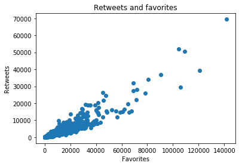

```python
df = pd.read_csv("cleaned_data.csv")

plt.scatter(df['favorite_count'], df['retweet_count'])
plt.xlabel('Favorites')
plt.ylabel('Retweets')
plt.title('Retweets and favorites')
```

```python
twitter_archive_df_copy["dog_stage"].dtype
#df.plot.bar(x='car_id')
```

```
CategoricalDtype(categories=['Doggo', 'Floofer', 'Multiple', 'None', 'Pupper', 'Puppo'], ordered=False)
```

```
Text(0.5,1,'Correlation Heat Map')
```

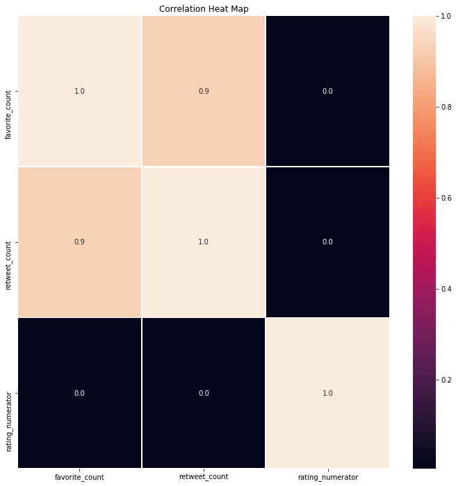

```python
#put up a correlation map
f,ax = plt.subplots(figsize=(12, 12))
sns.heatmap(df[['source','favorite_count','retweet_count','rating_numerator']].corr(), annot=True, linewidths=.8, fmt= '.1f',ax=ax)
plt.title('Correlation Heat Map')
```

- Strong correlation between favorites and retweets counts.

```
Text(0.5,0,'Dog Stage')
```

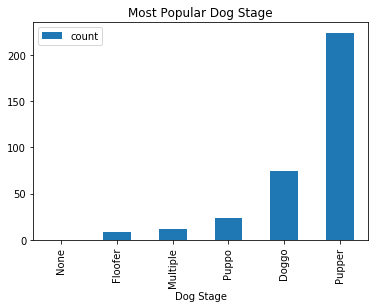

```python
dog_stages = twitter_archive_df_copy
dog_stages = dog_stages[dog_stages['dog_stage'] != 'None']
dog_stages = dog_stages.groupby('dog_stage').count()[['tweet_id']]
dog_stages.rename(columns={'tweet_id':'count'}, inplace=True)
dog_stages.sort_values(by=['count']).plot.bar()
plt.title("Most Popular Dog Stage")
plt.xlabel("Dog Stage")
```